[figure not shown]

| COMPONENTE CURRICULAR: | Propabilidade e Estatistica Aplicada |
| --- | --- |
| NOME COMPLETO DO ALUNO: | Nicolas Soares Santos |
| RA: | **10370082** |

# Exercício 1

Considere a base.

```r
require(stats)
head(stackloss)
```

```
##   Air.Flow Water.Temp Acid.Conc. stack.loss
## 1       80         27         89         42
## 2       80         27         88         37
## 3       75         25         90         37
## 4       62         24         87         28
## 5       62         22         87         18
## 6       62         23         87         18
```

```r
help(stackloss)
```

1.Qual a função linear que melhor aproxima stack.loss com base nos demais valores?

```r
# Ajustando o modelo de regressão linear
fit <- lm(stack.loss ~ Air.Flow + Water.Temp + Acid.Conc., data = stackloss)

# Exibindo o resumo do modelo
print(summary(fit))
```

```
##
## Call:
## lm(formula = stack.loss ~ Air.Flow + Water.Temp + Acid.Conc.,
##     data = stackloss)
##
## Residuals:
##     Min      1Q  Median      3Q     Max
## -7.2377 -1.7117 -0.4551  2.3614  5.6978
##
## Coefficients:
##             Estimate Std. Error t value Pr(>|t|)
## (Intercept) -39.9197    11.8960  -3.356  0.00375 **
## Air.Flow      0.7156     0.1349   5.307  5.8e-05 ***
## Water.Temp    1.2953     0.3680   3.520  0.00263 **
## Acid.Conc.   -0.1521     0.1563  -0.973  0.34405
## ---
## Signif. codes:  0 '***' 0.001 '**' 0.01 '*' 0.05 '.' 0.1 ' ' 1
##
## Residual standard error: 3.243 on 17 degrees of freedom
## Multiple R-squared:  0.9136, Adjusted R-squared:  0.8983
## F-statistic:  59.9 on 3 and 17 DF,  p-value: 3.016e-09
```

2.Faça uma predição do valor de stock.loss para os valores de Air.Flow=72, Water.Temp=20, Acid.Conc=85.

```r
# Criando um novo conjunto de dados para a predição
new_data <- data.frame(Air.Flow = 72, Water.Temp = 20, Acid.Conc. = 85)

# Fazendo a predição
prediction <- predict(fit, newdata = new_data)

# Exibindo o valor predito
print(prediction)
```

```
##        1
## 24.58173
```

```r
# Encontrando o valor real presente na base
real_value <- stackloss[stackloss$Air.Flow == 72 & stackloss$Water.Temp == 20 & stackloss$Acid.Conc. == 85, "stack.loss"]

# Calculando a diferença percentual
difference <- ((prediction - real_value) / real_value) * 100

# Exibindo a diferença percentual
print(difference)
```

```
## numeric(0)
```

4.Qual atributo contribui mais positivamente para o incremento de stackloss?

Isso pode ser identificado pelo coeficiente associado ao atributo (coeficientes maiores tem um efeito maior). Entretanto, as variáveis encontram-se em escalas diferentes e, portanto, você precisa normalizar os dados antes de observar os coeficientes da regressão. Você pode empregar a função abaixo para uma normalização min-max (levando todos valores de cada atributo ao intervalo [0,1]).

```r
normalize <- function(x) {
return ((x - min(x)) / (max(x) - min(x)))
}

stack_n = as.data.frame(lapply(stackloss, normalize))
summary(stack_n)
```

```
##     Air.Flow        Water.Temp       Acid.Conc.       stack.loss
##  Min.   :0.0000   Min.   :0.0000   Min.   :0.0000   Min.   :0.0000
##  1st Qu.:0.2000   1st Qu.:0.1000   1st Qu.:0.4762   1st Qu.:0.1143
##  Median :0.2667   Median :0.3000   Median :0.7143   Median :0.2286
##  Mean   :0.3476   Mean   :0.4095   Mean   :0.6803   Mean   :0.3007
##  3rd Qu.:0.4000   3rd Qu.:0.7000   3rd Qu.:0.8095   3rd Qu.:0.3429
##  Max.   :1.0000   Max.   :1.0000   Max.   :1.0000   Max.   :1.0000
```

```r
# Normalizando os dados
normalize <- function(x) {
  return ((x - min(x)) / (max(x) - min(x)))
}

stack_n <- as.data.frame(lapply(stackloss, normalize))

# Ajustando um novo modelo com dados normalizados
fit_n <- lm(stack.loss ~ Air.Flow + Water.Temp + Acid.Conc., data = stack_n)

# Exibindo os coeficientes do modelo ajustado
print(coefficients(fit_n))
```

```
##  (Intercept)     Air.Flow   Water.Temp   Acid.Conc.
## -0.002017762  0.613405886  0.370081750 -0.091273511
```

5.A regressão linear obtida é uma boa aproximação dos dados (R-squared > 0.85)? Qual o valor do (Multiple) R-squared obtido?

```r
# Exibindo o resumo do modelo para verificar o R-squared
print(summary(fit)$r.squared)
```

```
## [1] 0.9135769
```

# Exercício 2

Considere o exercício anterior. Elimine o atributo que não é significativo para a regressão e recalcule.

```r
# Ajustando um novo modelo sem o atributo não significativo (Acid.Conc.)
fit_new <- lm(stack.loss ~ Air.Flow + Water.Temp, data = stackloss)

# Exibindo o resumo do novo modelo
print(summary(fit_new))
```

```
##
## Call:
## lm(formula = stack.loss ~ Air.Flow + Water.Temp, data = stackloss)
##
## Residuals:
##     Min      1Q  Median      3Q     Max
## -7.5290 -1.7505  0.1894  2.1156  5.6588
##
## Coefficients:
##             Estimate Std. Error t value Pr(>|t|)
## (Intercept) -50.3588     5.1383  -9.801 1.22e-08 ***
## Air.Flow      0.6712     0.1267   5.298 4.90e-05 ***
## Water.Temp    1.2954     0.3675   3.525  0.00242 **
## ---
## Signif. codes:  0 '***' 0.001 '**' 0.01 '*' 0.05 '.' 0.1 ' ' 1
##
## Residual standard error: 3.239 on 18 degrees of freedom
## Multiple R-squared:  0.9088, Adjusted R-squared:  0.8986
## F-statistic: 89.64 on 2 and 18 DF,  p-value: 4.382e-10
```

Qual o novo valor do (Multiple) R-squared obtido?

```r
# Exibindo o novo valor de R-squared
print(summary(fit_new)$r.squared)
```

```
## [1] 0.9087609
```

3.Qual a função linear obtida?

```r
# Exibindo os coeficientes do novo modelo
print(coefficients(fit_new))
```

```
## (Intercept)    Air.Flow  Water.Temp
## -50.3588401   0.6711544   1.2953514
```

4.Modelos com com menos variáveis preditoras são modelos preferíveis pois assumem uma menor quantidade de hipóteses sobre os dados (procure na Internet, Occam’s razor ou princípio da parcimônia). Sendo a diferença do (Multiple) R-squared obtido no exercício anterior e nesta agora menor que 5%, este agora é um modelo melhor?

```r
# Calculando a diferença percentual dos R-squared
old_r_squared <- summary(fit)$r.squared
new_r_squared <- summary(fit_new)$r.squared

difference_percent <- ((new_r_squared - old_r_squared) / old_r_squared) * 100

# Verificando se a diferença é menor que 5%
if (abs(difference_percent) < 5) {
  print("Sim, o novo modelo é melhor.")
} else {
  print("Não, o modelo anterior é melhor.")
}
```

```
## [1] "Sim, o novo modelo é melhor."
```

# Exercício 3

Considere a base.

```r
df = read.csv('FuelConsumptionCo2.csv',header=T)
head(df)
```

```
##   MODELYEAR  MAKE      MODEL VEHICLECLASS ENGINESIZE CYLINDERS TRANSMISSION
## 1      2014 ACURA        ILX      COMPACT        2.0         4          AS5
## 2      2014 ACURA        ILX      COMPACT        2.4         4           M6
## 3      2014 ACURA ILX HYBRID      COMPACT        1.5         4          AV7
## 4      2014 ACURA    MDX 4WD  SUV - SMALL        3.5         6          AS6
## 5      2014 ACURA    RDX AWD  SUV - SMALL        3.5         6          AS6
## 6      2014 ACURA        RLX     MID-SIZE        3.5         6          AS6
##   FUELTYPE FUELCONSUMPTION_CITY FUELCONSUMPTION_HWY FUELCONSUMPTION_COMB
## 1        Z                  9.9                 6.7                  8.5
## 2        Z                 11.2                 7.7                  9.6
## 3        Z                  6.0                 5.8                  5.9
## 4        Z                 12.7                 9.1                 11.1
## 5        Z                 12.1                 8.7                 10.6
## 6        Z                 11.9                 7.7                 10.0
##   FUELCONSUMPTION_COMB_MPG CO2EMISSIONS
## 1                       33          196
## 2                       29          221
## 3                       48          136
## 4                       25          255
## 5                       27          244
## 6                       28          230
```

1.Construa um modelo de regressão e faça o gráfico da regressão obtida mostrando a aproximação com os dados.

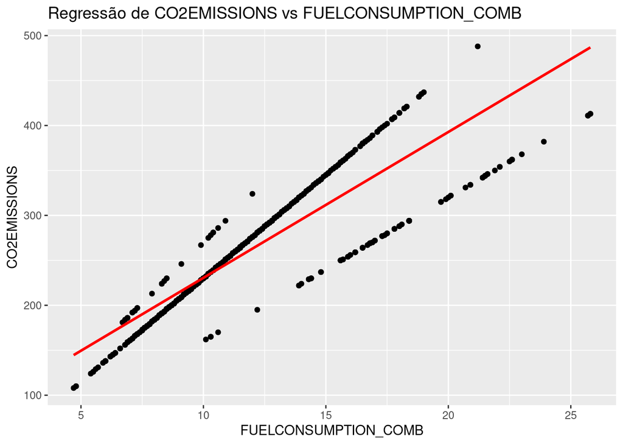

```r
# Carregando a biblioteca necessária
library(ggplot2)

# Construindo o modelo de regressão
fit <- lm(CO2EMISSIONS ~ FUELCONSUMPTION_COMB, data = df)

# Plotando o gráfico de dispersão com a reta de regressão
ggplot(df, aes(x = FUELCONSUMPTION_COMB, y = CO2EMISSIONS)) +
  geom_point() +
  geom_smooth(method = "lm", se = FALSE, color = "red") +
  labs(title = "Regressão de CO2EMISSIONS vs FUELCONSUMPTION_COMB",
       x = "FUELCONSUMPTION_COMB",
       y = "CO2EMISSIONS")
```

2.Qual o valor do (Multiple) R-squared obtido?

```r
# Exibindo o valor de R-squared
print(summary(fit)$r.squared)
```

```
## [1] 0.7958934
```

3.Estime as emissões de CO2EMISSIONS a partir de valores de FUELCONSUMPTION_COMB para os valores 10 e 25. Quais os valores obtidos?

```r
# Criando um novo conjunto de dados para predição
new_data <- data.frame(FUELCONSUMPTION_COMB = c(10, 25))

# Realizando a predição
predictions <- predict(fit, newdata = new_data)

# Exibindo as predições
print(predictions)
```

```
##        1        2
## 230.5868 473.8864
```

4.Acrescente ao seu modelo a variável de entrada ENGINESIZE.

```r
# Acrescentando a variável ENGINESIZE ao modelo
fit_with_enginesize <- lm(CO2EMISSIONS ~ FUELCONSUMPTION_COMB + ENGINESIZE, data = df)

# Exibindo o resumo do novo modelo
print(summary(fit_with_enginesize))
```

```
##
## Call:
## lm(formula = CO2EMISSIONS ~ FUELCONSUMPTION_COMB + ENGINESIZE,
##     data = df)
##
## Residuals:
##     Min      1Q  Median      3Q     Max
## -76.073  -8.749   1.089  13.490  74.589
##
## Coefficients:
##                      Estimate Std. Error t value Pr(>|t|)
## (Intercept)           78.3068     2.5793   30.36   <2e-16 ***
## FUELCONSUMPTION_COMB   9.7300     0.3662   26.57   <2e-16 ***
## ENGINESIZE            19.4963     0.9015   21.63   <2e-16 ***
## ---
## Signif. codes:  0 '***' 0.001 '**' 0.01 '*' 0.05 '.' 0.1 ' ' 1
##
## Residual standard error: 23.88 on 1064 degrees of freedom
## Multiple R-squared:  0.8582, Adjusted R-squared:  0.8579
## F-statistic:  3220 on 2 and 1064 DF,  p-value: < 2.2e-16
```

4.1. Qual a função linear obtida?

```r
# Exibindo os coeficientes do novo modelo
print(coefficients(fit_with_enginesize))
```

```
##          (Intercept) FUELCONSUMPTION_COMB           ENGINESIZE
##            78.306812             9.729959            19.496284
```

4.2. Qual o novo valor do (Multiple) R-squared obtido? Esse é um modelo melhor que o anterior?

```r
# Exibindo o valor de R-squared do novo modelo
print(summary(fit_with_enginesize)$r.squared)
```

```
## [1] 0.8582145
```

```r
# Comparando os R-squared dos dois modelos
if (summary(fit_with_enginesize)$r.squared > summary(fit)$r.squared) {
  print("Sim, o novo modelo é melhor que o anterior.")
} else {
  print("Não, o modelo anterior é melhor.")
}
```

```
## [1] "Sim, o novo modelo é melhor que o anterior."
```

5.Faça agora a predição de CO2EMISSIONS com base no modelo anterior, para FUELCONSUMPTION_COMB = 10 e ENGINESIZE=2. Qual o valor encontrado?

```r
# Criando um novo conjunto de dados para predição
new_data <- data.frame(FUELCONSUMPTION_COMB = 10, ENGINESIZE = 2)

# Realizando a predição
prediction <- predict(fit_with_enginesize, newdata = new_data)

# Exibindo a predição
print(prediction)
```

```
##       1
## 214.599
```